# Analisis ARDL Tinggi Muka Air (TMA) dengan Curah Hujan (PC) dan Kelembapan Relatif (RH)

Maulana Firdaus

2026-09-03

# 1 Pendahuluan

Dokumen ini memakai **sintaks dan data** analisis ARDL milik Kak Fajryanti, tetapi disederhanakan dari 4 peubah bebas (PC, TM, RH, WS) menjadi **2 peubah bebas** saja:

| Peubah | Keterangan | Peran |
| --- | --- | --- |
| `TMA` | Tinggi muka air (cm) | Peubah respon (Y) |
| `PC` | Curah hujan (mm) | Peubah bebas 1 |
| `RH` | Kelembapan relatif (%) | Peubah bebas 2 |

Data yang dipakai (harus berada satu folder dengan file Rmd ini):

- `Data_Harian_2022_2024.xlsx` : data harian 1 Jan 2022 – 31 Des 2024 (1.096 hari), dibagi menjadi data latih dan data uji.
- `Data_Jan25_Mar25.xlsx` : data harian 1 Jan 2025 – 31 Mar 2025 (90 hari), dipakai untuk peramalan di luar sampel.

# 2 Library

```r
library(readxl)
library(dplyr)
library(tidyr)
library(ggplot2)
library(patchwork)
library(corrplot)
library(moments)
library(forecast)
library(tseries)
library(lmtest)
library(car)
library(dLagM)
library(dynamac)
```

# 3 Import Data

```r
dataset <- read_excel("Data_Harian_2022_2024.xlsx")
dataset$Date <- as.Date(dataset$Date)

# Hanya TMA (respon), PC dan RH (peubah bebas) yang dipakai
dataset <- dataset[, c("Date", "TMA", "PC", "RH")]
str(dataset)
```

```
## tibble [1,096 x 4] (S3: tbl_df/tbl/data.frame)
##  $ Date: Date[1:1096], format: "2022-01-01" "2022-01-02" ...
##  $ TMA : num [1:1096] 595 588 580 576 574 ...
##  $ PC  : num [1:1096] 0.85 1.79 0.4 0.22 5.7 ...
##  $ RH  : num [1:1096] 86.4 88.1 83.2 80.3 83.2 ...
```

```r
head(dataset)
```

| Date | TMA | PC | RH |
| --- | --- | --- | --- |
| 2022-01-01 | 595.4167 | 0.85 | 86.38 |
| 2022-01-02 | 587.7083 | 1.79 | 88.13 |
| 2022-01-03 | 580.2083 | 0.40 | 83.20 |
| 2022-01-04 | 575.8333 | 0.22 | 80.29 |
| 2022-01-05 | 574.3750 | 5.70 | 83.16 |
| 2022-01-06 | 583.9583 | 9.45 | 85.55 |

# 4 Eksplorasi Data

## 4.1 Statistika Deskriptif

```r
summary(dataset)
```

```
##       Date                 TMA              PC                 RH
##  Min.   :2022-01-01   Min.   :555.4   Min.   :  0.0000   Min.   :67.03
##  1st Qu.:2022-10-01   1st Qu.:597.7   1st Qu.:  0.7375   1st Qu.:82.92
##  Median :2023-07-02   Median :620.0   Median :  4.0000   Median :86.29
##  Mean   :2023-07-02   Mean   :625.3   Mean   :  6.5700   Mean   :85.29
##  3rd Qu.:2024-04-01   3rd Qu.:650.1   3rd Qu.:  9.1325   3rd Qu.:88.53
##  Max.   :2024-12-31   Max.   :781.2   Max.   :145.0300   Max.   :94.31
```

```r
deskriptif <- data.frame(
  Peubah   = c("TMA", "PC", "RH"),
  SD       = c(sd(dataset$TMA, na.rm = TRUE), sd(dataset$PC, na.rm = TRUE), sd(dataset$RH, na.rm = TRUE)),
  Skewness = c(skewness(dataset$TMA, na.rm = TRUE), skewness(dataset$PC, na.rm = TRUE), skewness(dataset$RH, na.rm = TRUE)),
  Kurtosis = c(kurtosis(dataset$TMA, na.rm = TRUE), kurtosis(dataset$PC, na.rm = TRUE), kurtosis(dataset$RH, na.rm = TRUE))
)
deskriptif
```

| Peubah | SD | Skewness | Kurtosis |
| --- | --- | --- | --- |
| TMA | 39.449620 | 0.5304754 | 2.984404 |
| PC | 8.838259 | 5.0708708 | 62.196788 |
| RH | 4.710888 | -0.9881591 | 4.025032 |

## 4.2 Time Series

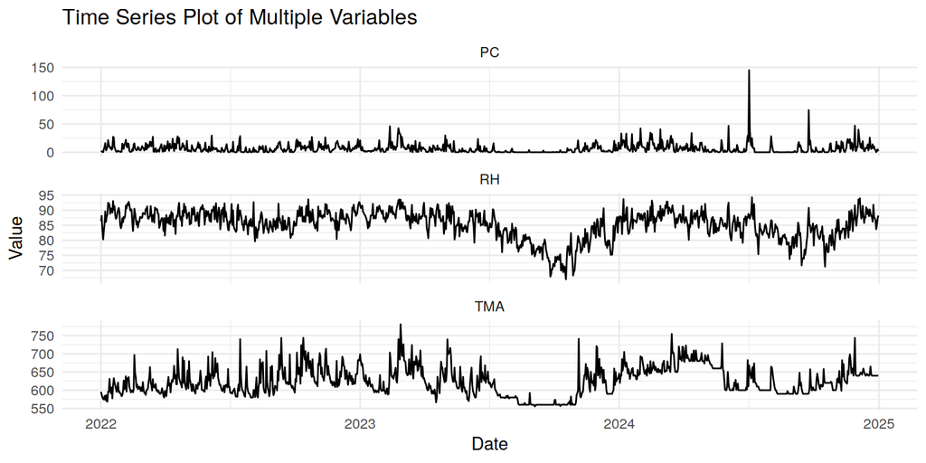

```r
data_long <- dataset %>%
  pivot_longer(cols = c(TMA, PC, RH), names_to = "Variabel", values_to = "Nilai")

ggplot(data_long, aes(x = Date, y = Nilai)) +
  geom_line() +
  facet_wrap(~ Variabel, scales = "free_y", ncol = 1) +
  labs(title = "Time Series Plot of Multiple Variables", x = "Date", y = "Value") +
  theme_minimal()
```

## 4.3 Matriks Korelasi

```r
cor_matrix <- cor(dataset[, c("TMA", "PC", "RH")], use = "complete.obs")
cor_matrix
```

```
##           TMA        PC        RH
## TMA 1.0000000 0.3945932 0.5250838
## PC  0.3945932 1.0000000 0.4196228
## RH  0.5250838 0.4196228 1.0000000
```

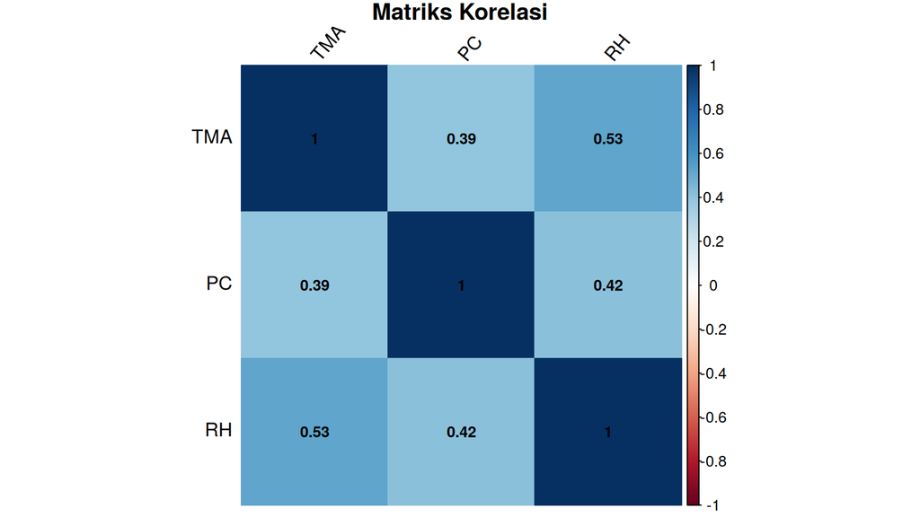

```r
corrplot(cor_matrix, method = "color", addCoef.col = "black",
         tl.col = "black", tl.srt = 50, number.cex = 0.8,
         title = "Matriks Korelasi", mar = c(0, 0, 1, 0))
```

# 5 Data Splitting

Data dibagi secara berurutan (tanpa diacak karena data deret waktu): **936 hari pertama sebagai data latih** dan **160 hari terakhir sebagai data uji** (sama seperti analisis aslinya).

```r
total_rows <- nrow(dataset)   # 1096
test_size  <- 160

train_index <- 1:(total_rows - test_size)
test_index  <- (total_rows - test_size + 1):total_rows

train_2225 <- dataset[train_index, ]
test_2225  <- dataset[test_index, ]

cat("Data latih:", nrow(train_2225), "hari (", format(min(train_2225$Date)), "s.d.", format(max(train_2225$Date)), ")\n")
```

```
## Data latih: 936 hari ( 2022-01-01 s.d. 2024-07-24 )
```

```r
cat("Data uji  :", nrow(test_2225),  "hari (", format(min(test_2225$Date)),  "s.d.", format(max(test_2225$Date)),  ")\n")
```

```
## Data uji  : 160 hari ( 2024-07-25 s.d. 2024-12-31 )
```

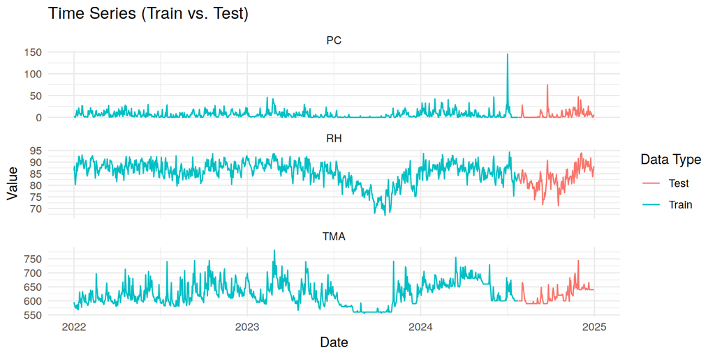

```r
combined_data <- bind_rows(
  train_2225 %>% mutate(DataType = "Train"),
  test_2225  %>% mutate(DataType = "Test")
)

data_long <- combined_data %>%
  pivot_longer(cols = c(TMA, PC, RH), names_to = "Variabel", values_to = "Nilai")

ggplot(data_long, aes(x = Date, y = Nilai, color = DataType)) +
  geom_line() +
  facet_wrap(~ Variabel, scales = "free_y", ncol = 1) +
  scale_color_manual(values = c("Train" = "#00BFC4", "Test" = "#F8766D")) +
  labs(title = "Time Series (Train vs. Test)", x = "Date", y = "Value", color = "Data Type") +
  theme_minimal()
```

# 6 Kestasioneran Data (Data Asli)

## 6.1 Plot ACF

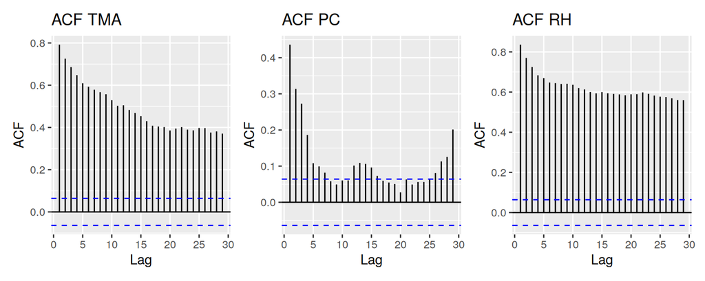

```r
acf_TMA <- ggAcf(train_2225$TMA) + labs(title = "ACF TMA")
acf_PC  <- ggAcf(train_2225$PC)  + labs(title = "ACF PC")
acf_RH  <- ggAcf(train_2225$RH)  + labs(title = "ACF RH")
acf_TMA + acf_PC + acf_RH
```

## 6.2 Plot PACF

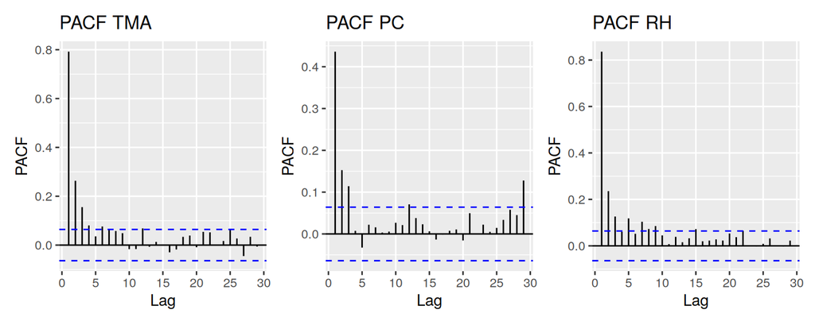

```r
pacf_TMA <- ggPacf(train_2225$TMA) + labs(title = "PACF TMA")
pacf_PC  <- ggPacf(train_2225$PC)  + labs(title = "PACF PC")
pacf_RH  <- ggPacf(train_2225$RH)  + labs(title = "PACF RH")
pacf_TMA + pacf_PC + pacf_RH
```

## 6.3 Uji ADF

Hipotesis: H0 = data tidak stasioner; H1 = data stasioner. Tolak H0 jika *p-value* < 0,05.

```r
adf.test(train_2225$TMA)
```

```
##
##  Augmented Dickey-Fuller Test
##
## data:  train_2225$TMA
## Dickey-Fuller = -4.0015, Lag order = 9, p-value = 0.01
## alternative hypothesis: stationary
```

```r
adf.test(train_2225$PC)
```

```
##
##  Augmented Dickey-Fuller Test
##
## data:  train_2225$PC
## Dickey-Fuller = -7.5589, Lag order = 9, p-value = 0.01
## alternative hypothesis: stationary
```

```r
adf.test(train_2225$RH)
```

```
##
##  Augmented Dickey-Fuller Test
##
## data:  train_2225$RH
## Dickey-Fuller = -3.3561, Lag order = 9, p-value = 0.06101
## alternative hypothesis: stationary
```

## 6.4 Plot CCF

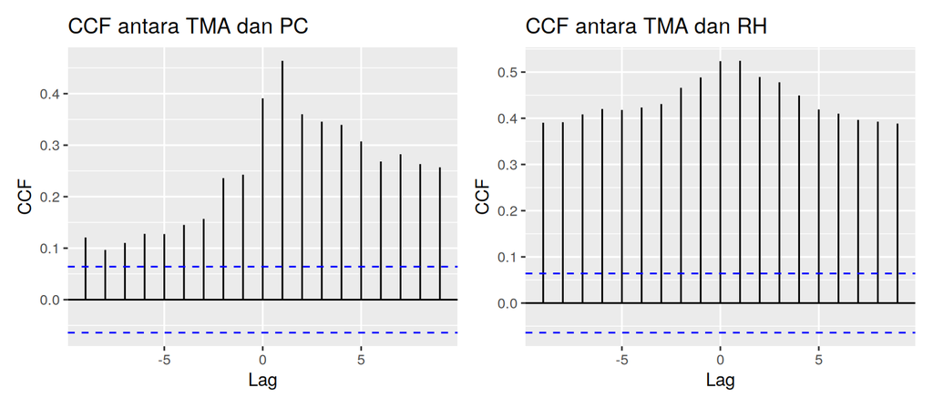

```r
ccf_result1 <- ggCcf(train_2225$TMA, train_2225$PC, lag.max = 9) + ggtitle("CCF antara TMA dan PC")
ccf_result2 <- ggCcf(train_2225$TMA, train_2225$RH, lag.max = 9) + ggtitle("CCF antara TMA dan RH")
ccf_result1 + ccf_result2
```

```r
ccf_pc <- ccf(train_2225$TMA, train_2225$PC, lag.max = 9, plot = FALSE)
ccf_rh <- ccf(train_2225$TMA, train_2225$RH, lag.max = 9, plot = FALSE)

ccf_all_df <- rbind(
  data.frame(Lag = ccf_pc$lag[, 1, 1], Correlation = ccf_pc$acf[, 1, 1], Pair = "TMA vs PC"),
  data.frame(Lag = ccf_rh$lag[, 1, 1], Correlation = ccf_rh$acf[, 1, 1], Pair = "TMA vs RH")
)
ccf_all_df
```

| Lag | Correlation | Pair |
| --- | --- | --- |
| -9 | 0.1207870 | TMA vs PC |
| -8 | 0.0965693 | TMA vs PC |
| -7 | 0.1101867 | TMA vs PC |
| -6 | 0.1277979 | TMA vs PC |
| -5 | 0.1273796 | TMA vs PC |
| -4 | 0.1451283 | TMA vs PC |
| -3 | 0.1568731 | TMA vs PC |
| -2 | 0.2359566 | TMA vs PC |
| -1 | 0.2426545 | TMA vs PC |
| 0 | 0.3908558 | TMA vs PC |
| 1 | 0.4637038 | TMA vs PC |
| 2 | 0.3599762 | TMA vs PC |
| 3 | 0.3456053 | TMA vs PC |
| 4 | 0.3394006 | TMA vs PC |
| 5 | 0.3072591 | TMA vs PC |
| 6 | 0.2682477 | TMA vs PC |
| 7 | 0.2823755 | TMA vs PC |
| 8 | 0.2632242 | TMA vs PC |
| 9 | 0.2569756 | TMA vs PC |
| -9 | 0.3903809 | TMA vs RH |
| -8 | 0.3914619 | TMA vs RH |
| -7 | 0.4084118 | TMA vs RH |
| -6 | 0.4200745 | TMA vs RH |
| -5 | 0.4179744 | TMA vs RH |
| -4 | 0.4233228 | TMA vs RH |
| -3 | 0.4308933 | TMA vs RH |
| -2 | 0.4659780 | TMA vs RH |
| -1 | 0.4884023 | TMA vs RH |
| 0 | 0.5236235 | TMA vs RH |
| 1 | 0.5243156 | TMA vs RH |
| 2 | 0.4893619 | TMA vs RH |
| 3 | 0.4779093 | TMA vs RH |
| 4 | 0.4493836 | TMA vs RH |
| 5 | 0.4190021 | TMA vs RH |
| 6 | 0.4100185 | TMA vs RH |
| 7 | 0.3963890 | TMA vs RH |
| 8 | 0.3926634 | TMA vs RH |
| 9 | 0.3885136 | TMA vs RH |

# 7 First Difference

## 7.1 Differencing

```r
DTMA <- diff(train_2225$TMA, differences = 1)
DPC  <- diff(train_2225$PC,  differences = 1)
DRH  <- diff(train_2225$RH,  differences = 1)

df <- data.frame(DTMA, DPC, DRH)
df.ts <- ts(df)
head(df)
```

| DTMA | DPC | DRH |
| --- | --- | --- |
| -7.708333 | 0.94 | 1.75 |
| -7.500000 | -1.39 | -4.93 |
| -4.375000 | -0.18 | -2.91 |
| -1.458333 | 5.48 | 2.87 |
| 9.583333 | 3.75 | 2.39 |
| -10.208333 | 6.72 | 4.06 |

## 7.2 Plot ACF

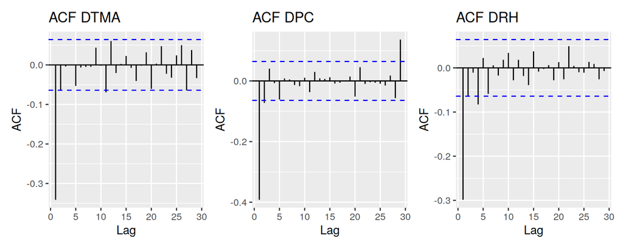

```r
acf_DTMA <- ggAcf(DTMA) + labs(title = "ACF DTMA")
acf_DPC  <- ggAcf(DPC)  + labs(title = "ACF DPC")
acf_DRH  <- ggAcf(DRH)  + labs(title = "ACF DRH")
acf_DTMA + acf_DPC + acf_DRH
```

## 7.3 Plot PACF

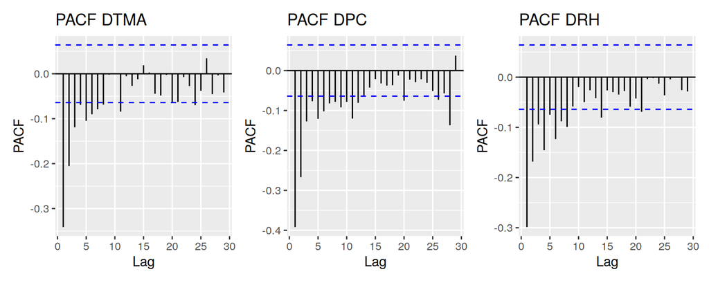

```r
pacf_DTMA <- ggPacf(DTMA) + labs(title = "PACF DTMA")
pacf_DPC  <- ggPacf(DPC)  + labs(title = "PACF DPC")
pacf_DRH  <- ggPacf(DRH)  + labs(title = "PACF DRH")
pacf_DTMA + pacf_DPC + pacf_DRH
```

## 7.4 Uji ADF

```r
adf.test(DTMA)
```

```
##
##  Augmented Dickey-Fuller Test
##
## data:  DTMA
## Dickey-Fuller = -12.518, Lag order = 9, p-value = 0.01
## alternative hypothesis: stationary
```

```r
adf.test(DPC)
```

```
##
##  Augmented Dickey-Fuller Test
##
## data:  DPC
## Dickey-Fuller = -14.984, Lag order = 9, p-value = 0.01
## alternative hypothesis: stationary
```

```r
adf.test(DRH)
```

```
##
##  Augmented Dickey-Fuller Test
##
## data:  DRH
## Dickey-Fuller = -13.91, Lag order = 9, p-value = 0.01
## alternative hypothesis: stationary
```

## 7.5 Plot CCF

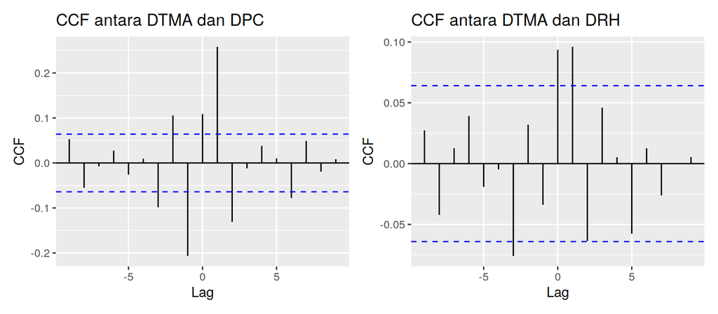

```r
ccf_d1 <- ggCcf(DTMA, DPC, lag.max = 9) + ggtitle("CCF antara DTMA dan DPC")
ccf_d2 <- ggCcf(DTMA, DRH, lag.max = 9) + ggtitle("CCF antara DTMA dan DRH")
ccf_d1 + ccf_d2
```

```r
ccf_dpc <- ccf(DTMA, DPC, lag.max = 9, plot = FALSE)
ccf_drh <- ccf(DTMA, DRH, lag.max = 9, plot = FALSE)

ccf_all_df_diff <- rbind(
  data.frame(Lag = ccf_dpc$lag[, 1, 1], Correlation = ccf_dpc$acf[, 1, 1], Pair = "DTMA vs DPC"),
  data.frame(Lag = ccf_drh$lag[, 1, 1], Correlation = ccf_drh$acf[, 1, 1], Pair = "DTMA vs DRH")
)
ccf_all_df_diff
```

| Lag | Correlation | Pair |
| --- | --- | --- |
| -9 | 0.0529586 | DTMA vs DPC |
| -8 | -0.0550552 | DTMA vs DPC |
| -7 | -0.0075649 | DTMA vs DPC |
| -6 | 0.0272775 | DTMA vs DPC |
| -5 | -0.0260688 | DTMA vs DPC |
| -4 | 0.0095201 | DTMA vs DPC |
| -3 | -0.0985237 | DTMA vs DPC |
| -2 | 0.1056948 | DTMA vs DPC |
| -1 | -0.2068571 | DTMA vs DPC |
| 0 | 0.1086869 | DTMA vs DPC |
| 1 | 0.2580986 | DTMA vs DPC |
| 2 | -0.1309037 | DTMA vs DPC |
| 3 | -0.0120557 | DTMA vs DPC |
| 4 | 0.0379024 | DTMA vs DPC |
| 5 | 0.0102911 | DTMA vs DPC |
| 6 | -0.0779872 | DTMA vs DPC |
| 7 | 0.0489951 | DTMA vs DPC |
| 8 | -0.0192893 | DTMA vs DPC |
| 9 | 0.0083649 | DTMA vs DPC |
| -9 | 0.0273578 | DTMA vs DRH |
| -8 | -0.0421465 | DTMA vs DRH |
| -7 | 0.0127059 | DTMA vs DRH |
| -6 | 0.0392241 | DTMA vs DRH |
| -5 | -0.0190855 | DTMA vs DRH |
| -4 | -0.0046866 | DTMA vs DRH |
| -3 | -0.0759844 | DTMA vs DRH |
| -2 | 0.0320355 | DTMA vs DRH |
| -1 | -0.0338906 | DTMA vs DRH |
| 0 | 0.0936044 | DTMA vs DRH |
| 1 | 0.0960395 | DTMA vs DRH |
| 2 | -0.0636944 | DTMA vs DRH |
| 3 | 0.0459606 | DTMA vs DRH |
| 4 | 0.0052088 | DTMA vs DRH |
| 5 | -0.0575980 | DTMA vs DRH |
| 6 | 0.0126319 | DTMA vs DRH |
| 7 | -0.0261257 | DTMA vs DRH |
| 8 | -0.0003283 | DTMA vs DRH |
| 9 | 0.0054044 | DTMA vs DRH |

# 8 ARDL dengan `dynardl` (paket dynamac)

## 8.1 Uji Kointegrasi (Bounds Test)

Uji batas Pesaran-Shin-Smith (2001) dengan `ardlBound` (paket `dLagM`), kasus 2, `max.p = 1`, `max.q = 9`. Jika statistik F melebihi batas atas I(1), maka terdapat kointegrasi (hubungan jangka panjang).

```r
# try(): beberapa versi paket strucchange gagal menggambar plot CUSUM di akhir fungsi
# (error "invalid font type"), padahal hasil uji sudah tercetak seluruhnya sebelum plot.
invisible(try(
  ardlBound(data = as.data.frame(train_2225),
            formula = TMA ~ PC + RH,
            case = 2, max.p = 1, max.q = 9),
  silent = TRUE
))
```

```
##
## Orders being calculated with max.p = 1 and max.q = 9 ...
##
## Autoregressive order: 10 and p-orders: 2 1
## ------------------------------------------------------
##
##  Breusch-Godfrey Test for the autocorrelation in residuals:
##
##  Breusch-Godfrey test for serial correlation of order up to 1
##
## data:  modelFull$model
## LM test = 1.5157, df1 = 1, df2 = 909, p-value = 0.2186
##
## ------------------------------------------------------
##
##  Ljung-Box Test for the autocorrelation in residuals:
##
##  Box-Ljung test
##
## data:  res
## X-squared = 0.023902, df = 1, p-value = 0.8771
##
## ------------------------------------------------------
##
##  Breusch-Pagan Test for the homoskedasticity of residuals:
##
##  studentized Breusch-Pagan test
##
## data:  modelFull$model
## BP = 199.46, df = 15, p-value < 2.2e-16
##
## The p-value of Breusch-Pagan test for the homoskedasticity of residuals:  2.734809e-34 < 0.05!
## ------------------------------------------------------
##
##  Shapiro-Wilk test of normality of residuals:
##
##  Shapiro-Wilk normality test
##
## data:  modelFull$model$residual
## W = 0.88703, p-value < 2.2e-16
```

[output cut: 20 more lines]

```
##
##  ------------------------------------------------------
##  F-statistic note: Asymptotic critical values used.
##
## ------------------------------------------------------
##
##  Ramsey's RESET Test for model specification:
##
##  RESET test
##
## data:  modelECM$model
## RESET = 22.582, df1 = 2, df2 = 911, p-value = 2.68e-10
##
## the p-value of RESET test:  2.680349e-10 < 0.05!
## ------------------------------------------------------
```

```
## ------------------------------------------------------
## Error Correction Model Output:
##
## Time series regression with "ts" data:
## Start = 10, End = 935
##
## Call:
## dynlm(formula = as.formula(model.text), data = data)
##
## Residuals:
##      Min       1Q   Median       3Q      Max
## -130.086  -11.717   -2.635    6.745  136.100
##
## Coefficients:
##        Estimate Std. Error t value Pr(>|t|)
## ec.1   -0.17775    0.01577 -11.272  < 2e-16 ***
## dPC.t   0.67150    0.09149   7.340 4.73e-13 ***
## dPC.1   0.35361    0.09905   3.570 0.000376 ***
## dRH.t   0.71637    0.27437   2.611 0.009176 **
## dTMA.1 -0.42205    0.03010 -14.023  < 2e-16 ***
## dTMA.2 -0.27043    0.03320  -8.146 1.23e-15 ***
## dTMA.3 -0.19856    0.03398  -5.844 7.10e-09 ***
## dTMA.4 -0.12458    0.03440  -3.621 0.000309 ***
## dTMA.5 -0.14675    0.03396  -4.322 1.72e-05 ***
## dTMA.6 -0.12230    0.03394  -3.603 0.000332 ***
## dTMA.7 -0.09617    0.03356  -2.865 0.004262 **
## dTMA.8 -0.04125    0.03250  -1.269 0.204753
## dTMA.9  0.02274    0.02935   0.775 0.438574
## ---
## Signif. codes:  0 '***' 0.001 '**' 0.01 '*' 0.05 '.' 0.1 ' ' 1
##
## Residual standard error: 21.23 on 913 degrees of freedom
## Multiple R-squared:  0.3707, Adjusted R-squared:  0.3618
## F-statistic: 41.37 on 13 and 913 DF,  p-value: < 2.2e-16
##
## ------------------------------------------------------
## Long-run coefficients:
##      TMA.1       PC.1       RH.1
## -0.1777542  1.2022135  0.3960311
##
```

## 8.2 Model

### 8.2.1 Jangka Pendek (Error Correction pada data differencing)

```r
modelardl <- dynardl(
  DTMA ~ DPC + DRH,
  data = df,
  lags = list(
    "DTMA" = 1:9,
    "DPC"  = 1,
    "DRH"  = 1
  ),
  ec = TRUE
)
```

```
## [1] "Error correction (EC) specified; dependent variable to be run in differences."
```

```r
summary(modelardl)
```

```
##
## Call:
## lm(formula = as.formula(paste(paste(dvnamelist), "~", paste(colnames(IVs),
##     collapse = "+"), collapse = " ")))
##
## Residuals:
##     Min      1Q  Median      3Q     Max
## -82.905 -11.899  -3.051   7.310 140.121
##
## Coefficients:
##             Estimate Std. Error t value Pr(>|t|)
## (Intercept)  0.07954    0.75371   0.106 0.915980
## l.1.DTMA    -1.48549    0.03170 -46.861  < 2e-16 ***
## l.2.DTMA    -0.26216    0.03553  -7.378 3.60e-13 ***
## l.3.DTMA    -0.20926    0.03615  -5.788 9.76e-09 ***
## l.4.DTMA    -0.12204    0.03682  -3.315 0.000954 ***
## l.5.DTMA    -0.16120    0.03649  -4.418 1.12e-05 ***
## l.6.DTMA    -0.12655    0.03656  -3.461 0.000563 ***
## l.7.DTMA    -0.10256    0.03618  -2.835 0.004685 **
## l.8.DTMA    -0.05487    0.03493  -1.571 0.116531
## l.9.DTMA     0.02288    0.03169   0.722 0.470456
## l.1.DPC      0.72043    0.08740   8.243 5.79e-16 ***
## l.1.DRH      0.62171    0.29720   2.092 0.036725 *
## ---
## Signif. codes:  0 '***' 0.001 '**' 0.01 '*' 0.05 '.' 0.1 ' ' 1
##
## Residual standard error: 22.94 on 914 degrees of freedom
##   (9 observations deleted due to missingness)
## Multiple R-squared:  0.726,  Adjusted R-squared:  0.7227
## F-statistic: 220.1 on 11 and 914 DF,  p-value: < 2.2e-16
```

```r
AIC(modelardl$model)
```

```
## [1] 8443.511
```

### 8.2.2 Jangka Panjang (data level)

```r
modelardll <- dynardl(
  formula = TMA ~ PC + RH,
  data = train_2225,
  levels = c("PC", "RH"),
  ec = FALSE
)
```

```
## [1] "Dependent variable to be run in levels."
```

```r
summary(modelardll)
```

```
##
## Call:
## lm(formula = as.formula(paste(paste(dvnamelist), "~", paste(colnames(IVs),
##     collapse = "+"), collapse = " ")))
##
## Residuals:
##     Min      1Q  Median      3Q     Max
## -81.035 -12.390  -3.133   8.906 138.920
##
## Coefficients:
##             Estimate Std. Error t value Pr(>|t|)
## (Intercept) 99.84097   16.21708   6.157 1.10e-09 ***
## l.1.TMA      0.69406    0.02133  32.540  < 2e-16 ***
## PC           0.83239    0.09610   8.662  < 2e-16 ***
## RH           1.00643    0.19987   5.035 5.73e-07 ***
## ---
## Signif. codes:  0 '***' 0.001 '**' 0.01 '*' 0.05 '.' 0.1 ' ' 1
##
## Residual standard error: 23.34 on 931 degrees of freedom
##   (1 observation deleted due to missingness)
## Multiple R-squared:  0.6785, Adjusted R-squared:  0.6775
## F-statistic:   655 on 3 and 931 DF,  p-value: < 2.2e-16
```

```r
AIC(modelardll$model)
```

```
## [1] 8550.505
```

## 8.3 Uji Asumsi

```r
res1 <- residuals(modelardl$model)

# Autokorelasi sisaan (H0: tidak ada autokorelasi)
Box.test(res1, lag = 20, type = "Ljung-Box")
```

```
##
##  Box-Ljung test
##
## data:  res1
## X-squared = 19.038, df = 20, p-value = 0.5193
```

```r
# Normalitas sisaan (H0: sisaan menyebar normal)
jarque.bera.test(res1)
```

```
##
##  Jarque Bera Test
##
## data:  res1
## X-squared = 1281.6, df = 2, p-value < 2.2e-16
```

```r
# Homoskedastisitas (H0: ragam sisaan homogen)
fitted_val1 <- fitted(modelardl$model)
bptest(res1 ~ fitted_val1)
```

```
##
##  studentized Breusch-Pagan test
##
## data:  res1 ~ fitted_val1
## BP = 1.3632, df = 1, p-value = 0.243
```

```r
# Multikolinearitas (VIF < 10 berarti aman)
vif(modelardl$model)
```

```
## l.1.DTMA l.2.DTMA l.3.DTMA l.4.DTMA l.5.DTMA l.6.DTMA l.7.DTMA l.8.DTMA
## 1.249782 1.570812 1.626521 1.687545 1.657613 1.664197 1.629196 1.518988
## l.9.DTMA  l.1.DPC  l.1.DRH
## 1.250541 1.153269 1.097102
```

# 9 Evaluasi Model pada Data Latih

Prediksi selisih TMA dihitung dari koefisien `l.1.DPC` dan `l.1.DRH` model jangka pendek, lalu diakumulasikan menjadi nilai TMA: *TMA<sub>t</sub> = TMA<sub>t-1</sub> + ΔTMA<sub>t</sub>*.

```r
evaluasi <- function(aktual, prediksi) {
  data.frame(
    MAE  = mean(abs(prediksi - aktual), na.rm = TRUE),
    RMSE = sqrt(mean((prediksi - aktual)^2, na.rm = TRUE)),
    MAPE = mean(abs((aktual - prediksi) / aktual), na.rm = TRUE) * 100
  )
}

# Fungsi untuk meramal: pakai koefisien model jangka pendek, lalu akumulasikan dari nilai awal
ramal_tma <- function(data_diff, tma_awal, model) {
  coefs <- summary(model)$coefficients
  data_diff$DTMA_pred <- coefs["(Intercept)", "Estimate"] +
    coefs["l.1.DPC", "Estimate"] * data_diff$DPC +
    coefs["l.1.DRH", "Estimate"] * data_diff$DRH
  data_diff$TMA_pred <- tma_awal + cumsum(data_diff$DTMA_pred)
  data_diff
}
```

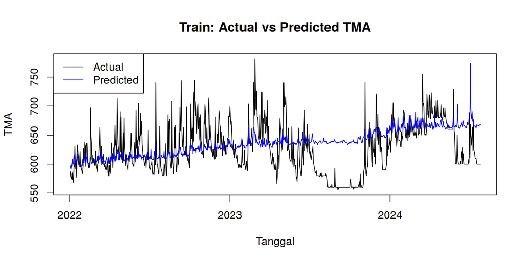

```r
train_baru <- data.frame(DPC, DRH)
train_baru <- ramal_tma(train_baru, tma_awal = train_2225$TMA[1], model = modelardl)

TMA_actual_train <- train_2225$TMA[-1]   # -1 karena differencing
TMA_pred_train   <- train_baru$TMA_pred

plot(train_2225$Date[-1], TMA_actual_train, type = "l", col = "black",
     main = "Train: Actual vs Predicted TMA", xlab = "Tanggal", ylab = "TMA")
lines(train_2225$Date[-1], TMA_pred_train, col = "blue")
legend("topleft", legend = c("Actual", "Predicted"), col = c("black", "blue"), lty = 1)
```

```r
evaluasi(TMA_actual_train, TMA_pred_train)
```

| MAE | RMSE | MAPE |
| --- | --- | --- |
| 31.66414 | 41.07022 | 5.13037 |

# 10 Evaluasi Model pada Data Uji

Data uji (160 hari terakhir) diramal dimulai dari nilai TMA terakhir data latih.

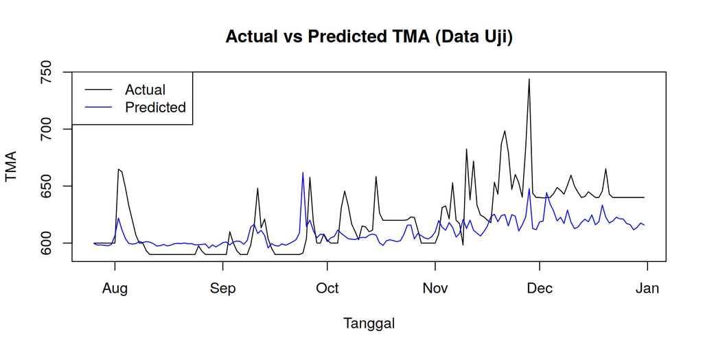

```r
TDPC <- diff(test_2225$PC, differences = 1)
TDRH <- diff(test_2225$RH, differences = 1)

test_baru <- data.frame(DPC = TDPC, DRH = TDRH)
last_TMA_train <- tail(train_2225$TMA, 1)
test_baru <- ramal_tma(test_baru, tma_awal = last_TMA_train, model = modelardl)

TMA_actual_test <- test_2225$TMA[-1]
TMA_pred_test   <- test_baru$TMA_pred
date_seq        <- test_2225$Date[-1]

plot(date_seq, TMA_actual_test, type = "l", col = "black",
     main = "Actual vs Predicted TMA (Data Uji)", xlab = "Tanggal", ylab = "TMA",
     ylim = range(c(TMA_actual_test, TMA_pred_test)))
lines(date_seq, TMA_pred_test, col = "blue")
legend("topleft", legend = c("Actual", "Predicted"), col = c("black", "blue"), lty = 1)
```

```r
evaluasi(TMA_actual_test, TMA_pred_test)
```

| MAE | RMSE | MAPE |
| --- | --- | --- |
| 18.02884 | 24.49108 | 2.819428 |

# 11 Peramalan Januari – Maret 2025

Model yang sama dipakai untuk meramal TMA periode 1 Januari – 31 Maret 2025 dengan `Data_Jan25_Mar25.xlsx`. Nilai TMA awal diambil dari data aktual 1 Januari 2025.

```r
data_2025 <- read_excel("Data_Jan25_Mar25.xlsx")
data_2025$Date <- as.Date(data_2025$Date)

DPC_25 <- diff(data_2025$PC, differences = 1)
DRH_25 <- diff(data_2025$RH, differences = 1)

test_25 <- data.frame(DPC = DPC_25, DRH = DRH_25)
test_25 <- ramal_tma(test_25, tma_awal = data_2025$TMA[1], model = modelardl)

hasil_prediksi <- data.frame(
  date       = data_2025$Date[-1],
  TMA_actual = data_2025$TMA[-1],
  TMA_pred   = test_25$TMA_pred
)
head(hasil_prediksi, 10)
```

| date | TMA_actual | TMA_pred |
| --- | --- | --- |
| 2025-01-02 | 640.0000 | 637.0512 |
| 2025-01-03 | 640.0000 | 640.0706 |
| 2025-01-04 | 640.0000 | 640.5603 |
| 2025-01-05 | 640.0000 | 637.0962 |
| 2025-01-06 | 640.0000 | 653.5259 |
| 2025-01-07 | 640.0000 | 646.5268 |
| 2025-01-08 | 641.4583 | 655.8792 |
| 2025-01-09 | 666.2500 | 654.3403 |
| 2025-01-10 | 642.5000 | 643.4396 |
| 2025-01-11 | 637.5000 | 648.2091 |

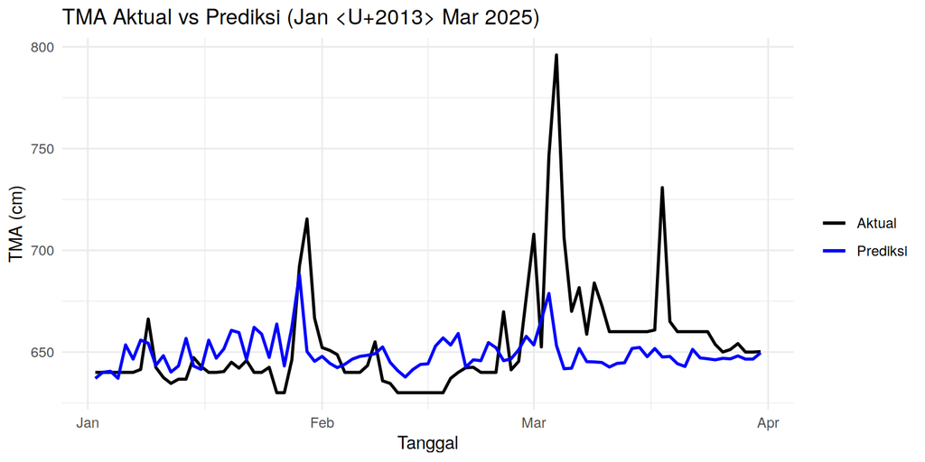

```r
ggplot(hasil_prediksi, aes(x = date)) +
  geom_line(aes(y = TMA_actual, color = "Aktual"), linewidth = 0.9) +
  geom_line(aes(y = TMA_pred,   color = "Prediksi"), linewidth = 0.9) +
  scale_color_manual(values = c("Aktual" = "black", "Prediksi" = "blue")) +
  labs(title = "TMA Aktual vs Prediksi (Jan – Mar 2025)",
       x = "Tanggal", y = "TMA (cm)", color = "") +
  theme_minimal()
```

```r
evaluasi(hasil_prediksi$TMA_actual, hasil_prediksi$TMA_pred)
```

| MAE | RMSE | MAPE |
| --- | --- | --- |
| 16.18396 | 25.94375 | 2.386003 |

```r
# Opsional: simpan hasil peramalan ke Excel
# library(writexl)
# write_xlsx(hasil_prediksi, path = "hasil_peramalan.xlsx")
```

# 12 Catatan

- Peubah bebas hanya **PC** dan **RH**; peubah TM dan WS dari analisis asli tidak diikutkan.
- Hasil angka (koefisien, uji, MAE/RMSE/MAPE) otomatis dihitung ulang setiap kali Rmd di-*knit*.
- Skema peramalan mengikuti analisis aslinya: hanya koefisien PC dan RH yang dipakai pada nilai selisih hari yang sama, sehingga kesalahan prediksi dapat menumpuk pada horizon yang panjang.